# matplotlib-1

## 二、设置plot的风格和样式

plot语句中支持除X,Y以外的参数，以字符串形式存在，来控制颜色、线型、点型等要素，语法形式为：  
plt.plot(X, Y, 'format', ...)

### 点和线的样式

#### 颜色

参数color或c

```
(-1.1, 1.1, -1.0999438818457405, 1.0999438818457405)
```

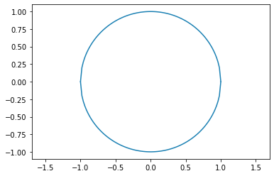

```python
x = np.linspace(-1, 1, 100)
y = (1 - x **2) **0.5
plt.plot(x, y, x, -y, c=(0.1, 0.5, 0.7))
plt.axis('equal')
```

##### 颜色值的方式

- 别名
  - color='r'
- 合法的HTML颜色名
  - color = 'red'

| 颜色 | 别名 | HTML颜色名 | 颜色 | 别名 | HTML颜色名 |
| --- | --- | --- | --- | --- | --- |
| 蓝色 | b | blue | 绿色 | g | green |
| 红色 | r | red | 黄色 | y | yellow |
| 青色 | c | cyan | 黑色 | k | black |
| 洋红色 | m | magenta | 白色 | w | white |

- HTML十六进制字符串
  - color = '#eeefff'
- 归一化到[0, 1]的RGB元组
  - color = (0.3, 0.3, 0.4)

##### 透明度

alpha参数

```
(-1.1, 1.1, -1.0999438818457405, 1.0999438818457405)
```

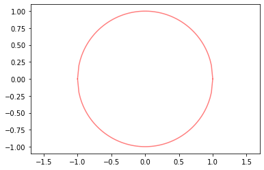

```python
x = np.linspace(-1, 1, 100)
y = (1 - x **2) **0.5
# 透明度是从0到1之间
plt.plot(x, y, x, -y, c='r', alpha=0.5)
plt.axis('equal')
```

##### 背景色

设置背景色，通过plt.subplot()方法传入facecolor参数，来设置坐标轴的背景色

```
(-1.1, 1.1, -1.0999438818457405, 1.0999438818457405)
```

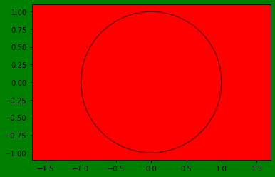

```python
figure = plt.figure(facecolor='g')
x = np.linspace(-1, 1, 100)
y = (1 - x **2) **0.5
# 透明度是从0到1之间
plt.subplot(facecolor='r')
plt.plot(x, y, x, -y, c='k', alpha=0.5)
plt.axis('equal')
```

#### 线型

参数linestyle或ls

| 线条风格 | 描述 | 线条风格 | 描述 |
| --- | --- | --- | --- |
| '-' | 实线 | ':' | 虚线 |
| '--' | 破折线 | 'steps' | 阶梯线 |
| '-.' | 点划线 | 'None' / '，' | 什么都不画 |

```
(-1.1, 1.1, -1.0931887889998972, 1.0931887889998972)
```

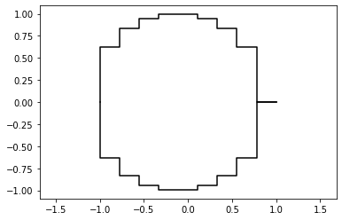

```python
x = np.linspace(-1, 1, 10)
y = (1 - x **2) **0.5
# 透明度是从0到1之间
plt.plot(x, y, x, -y, c='k', alpha=1, linestyle='steps')
plt.axis('equal')
```

##### 线宽

linewidth或lw参数

```
(-1.1, 1.1, -1.0999438818457405, 1.0999438818457405)
```

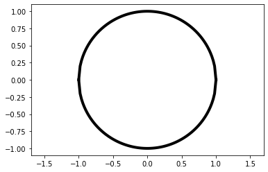

```python
x = np.linspace(-1, 1, 100)
y = (1 - x **2) **0.5
# 透明度是从0到1之间
plt.plot(x, y, x, -y, c='k', alpha=1, lw=4)
plt.axis('equal')
```

##### 不同宽度的破折线

dashes参数  
设置破折号序列各段的宽度

[figure not shown]

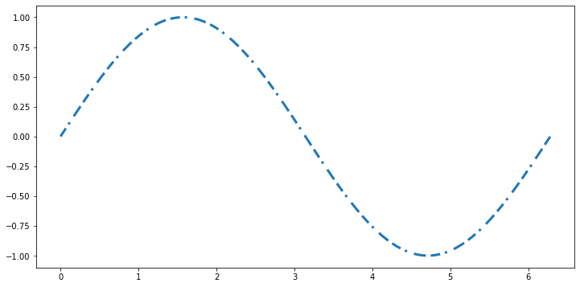

```python
plt.figure(figsize=(12,6))
x = np.linspace(0,2 * np.pi,  100)
y = np.sin(x)
plt.plot(x,y, dashes=[4, 2, 1, 3, 5, 2], lw=3)
```

#### 点型

marker参数

| 标记 | 描述 | 标记 | 描述 |
| --- | --- | --- | --- |
| '1' | 一角朝下的三脚架 | '3' | 一角朝左的三脚架 |
| '2' | 一角朝上的三脚架 | '4' | 一角朝右的三脚架 |

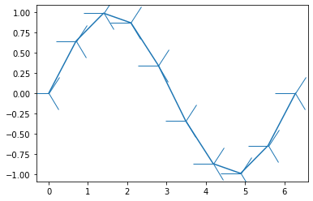

```python
x = np.linspace(0, 2*np.pi ,10)
y = np.sin(x)
plt.plot(x,y, marker='3', markersize=50)
```

| 标记 | 描述 | 标记 | 描述 |
| --- | --- | --- | --- |
| 's' | 正方形 | 'p' | 五边形 |
| 'h' | 六边形1 | 'H' | 六边形2 |
| '8' | 八边形 |  |  |

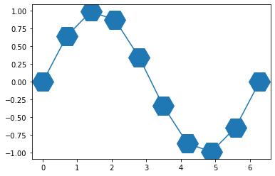

```python
x = np.linspace(0, 2*np.pi ,10)
y = np.sin(x)
plt.plot(x,y, marker='H', markersize=30)
```

| 标记 | 描述 | 标记 | 描述 |
| --- | --- | --- | --- |
| '.' | 点 | 'x' | X |
| '*' | 星号 | '+' | 加号 |
| ',' | 像素 |  |  |

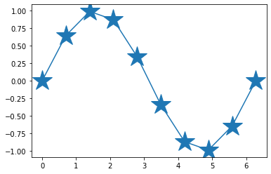

```python
x = np.linspace(0, 2*np.pi ,10)
y = np.sin(x)
plt.plot(x,y, marker='*', markersize=30)
```

| 标记 | 描述 | 标记 | 描述 |
| --- | --- | --- | --- |
| 'o' | 圆圈 | 'D' | 菱形 |
| 'd' | 小菱形 | '','None',' ',None | 无 |

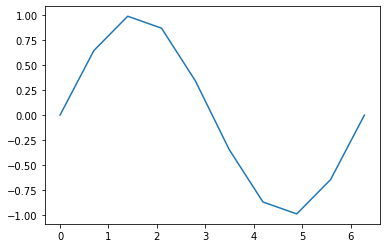

```python
x = np.linspace(0, 2*np.pi ,10)
y = np.sin(x)
plt.plot(x,y, marker='None', markersize=30)
```

[output not shown]

[figure not shown]

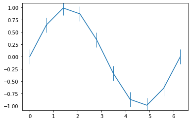

```python
x = np.linspace(0, 2*np.pi ,10)
y = np.sin(x)
plt.plot(x,y, marker='|', markersize=30)
```

| 标记 | 描述 | 标记 | 描述 |
| --- | --- | --- | --- |
| 'v' | 一角朝下的三角形 | '<' | 一角朝左的三角形 |
| '^' | 一角朝上的三角形 | '>' | 一角朝右的三角形 |

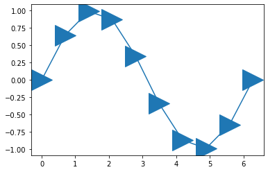

```python
x = np.linspace(0, 2*np.pi ,10)
y = np.sin(x)
plt.plot(x,y, marker='>', markersize=30)
```